# Modelo Camp_Tarea

Iván Arellano, Juan Pablo Rodriguez, Santiago Romero

28/9/2021

### Introducción

Se creará un portafolio con diversos activos, variando en ponderación de cada uno de los seleccionados, con el fin de llegar a un portafolio que tenga un % de riesgo no sistemático menor al 60%, y buscando encontrar un alpha adecuada, maximizándola sin sacrificar el porcentaje ya mencionado.

Con un total de 80 acciones, las repartimos entre los activos, de la siguiente manera: - América Móvil 10 acciones - Walmart México 10 acciones - FEMSA 7 acciones - Banorte 11 acciones - CEMEX 9 acciones - Grupo México 9 acciones - Bimbo 4 acciones - Qualitas 15 acciones - Arca Continental 5 acciones

¿Cómo seleccionamos estos activos?

En base a la información de las empresas principales de distintos ETF’s, y haciendo nosotros nuestro propio análisis técnico de los históricos. Utilizamos también [Investing](https://mx.investing.com/equities/) y [Yahoo Finance](https://finance.yahoo.com/etfs), donde cada uno tiene su propia lista con los mejores activos, filtramos de México y nos pusimos a seleccionar. Fue básicamente prueba y error para llegar a los resultados deseados.

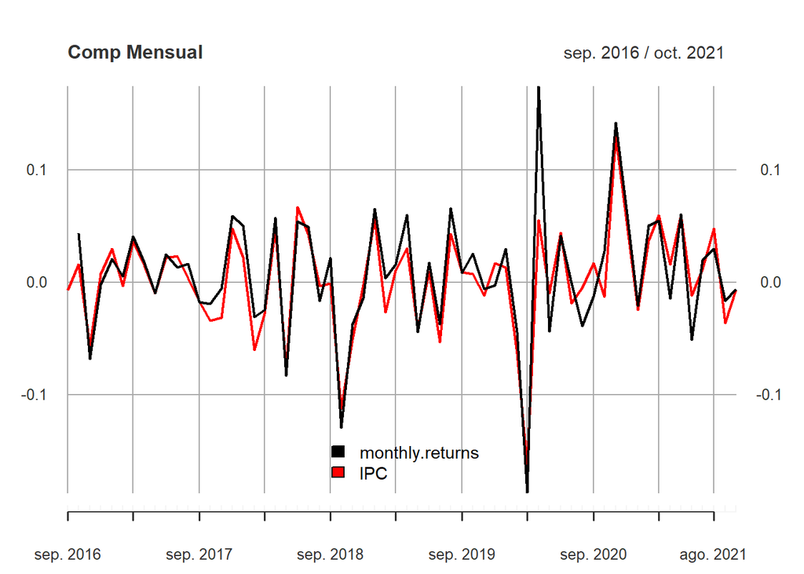

```r
plot(merge.xts(port_renm, m_renm), main="Comp Mensual", legend.loc="bottom")
```

```r
Resultados <- tibble("Riesgo Total"=RT, "Riesgo Sistemático"=RT*RC, "Riesgo No Sistemático"=RT*(1-RC), "% de Riesgo Sistemático"=RC*100, "% Riesgo No Sistemático"=(1-RC)*100, "Beta"=Beta, "Alpha"=Alpha)
Resultados
```

```
## # A tibble: 1 x 7
##   `Riesgo Total` `Riesgo Sistemático` `Riesgo No Sistemático` `% de Riesgo Sist~
##            <dbl>                <dbl>                   <dbl>              <dbl>
## 1          0.305                0.253                  0.0525               82.8
## # ... with 3 more variables: % Riesgo No Sistemático <dbl>, Beta <dbl>,
## #   Alpha <dbl>
```

### Conclusión

Al final, obtenemos un portafolio con un porcentaje de riesgo no sistemático del 17.21% y un alpha de 0.00528, pensamos que es un portafolio conservador pero que nos generará buenos rendimientos.